# Sensitivity of LB-SPR to life history parameters M/k and Linf. The case of Pollack89a.

María Paz Sampedro

14/10/2020

#### Download library

```r
library(LBSPR)
```

#### Data for pollack

##### Life history parameters from literature

- M/k ratio: ${M/k}^{LIT}$=1.648352 (k 0.182 year-1 y M=0.3 (Alemany, 2017)).
- Linf von Bertalanffy parameter: $L_{inf}^{LIT}$= 98.2 cm For stock in ICES Division 7 (Alemany, 2017).
- Natural mortality, M = 0.3 (Alemany, 2017)
- Length at 50% of Maturity, L50= 42.3 cm (Alonso-Fernández etal, 2013)
- Length at 95% of Maturity, L95= 59 cm

Create an object L_pars:

```r
Pol1 <- new("LB_pars")
Pol1@Linf <- 98.2
Pol1@CVLinf <- 0.1 # by default
Pol1@L50 <- 42.3
Pol1@L95 <- 59 # estimated from figure (Alonso-Fernández etal, 2013)
Pol1@MK <- 0.3/0.182
Pol1@M <- 0.3
Pol1@SL50 <- 47.5
Pol1@SL95 <- 69
Pol1@SPR <- 0.4
Pol1@Walpha <- 0.00001
Pol1@Wbeta <- 3.0044
Pol1@BinWidth <- 4
MySim <- LBSPRsim(Pol1)
Pol1@BinMax <- 130
Pol1@BinMin <- 0
Pol1@L_units <- "cm"
```

##### Import Length frequencies and create object LB_length:

```r
Len1 <- new("LB_lengths", LB_pars=Pol1, file=("pol89aSPR_MultYr4cm.csv"), dataType="freq",header=TRUE)
```

### Scenarios

#### Reference Case

The **Reference Case** scenario uses the parameters ${M/k}^{LIT}$ and $L_{inf}^{LIT}$. The results from alterntive scenarios, with different values for $L_{inf}$ and ${M/k}$ will be compared with the reference case results.

```r
Fit1 <- LBSPRfit(Pol1, Len1)
```

#### Scenarios for different values of M/k

1. Underestimate ${M/k}^{LIT}$, multiplying by the factor 0.75:

```r
Pol0.75MK <- Pol1
Pol0.75MK@MK <- 0.75*Pol1@MK
Pol0.75LenMK <- new("LB_lengths",  LB_pars=Pol0.75MK, file="pol89aSPR_MultYr4cm.csv", dataType="freq", header=TRUE)
Pol0.75LenMK@L_units <- Pol0.75MK@L_units
Fit0.75MK <- LBSPRfit(Pol0.75MK, Pol0.75LenMK)
```

2. Overestimate ${M/k}^{LIT}$ multiplying by the factor 1.25:

```r
Pol1.25MK <- Pol1
Pol1.25MK@MK <- 1.25*Pol1@MK
Pol1.25LenMK <- new("LB_lengths", LB_pars=Pol1.25MK, file="pol89aSPR_MultYr4cm.csv", dataType="freq", header=TRUE)
Pol1.25LenMK@L_units <- Pol1.25MK@L_units
Fit1.25MK <- LBSPRfit(Pol1.25MK, Pol1.25LenMK)
```

3. Using the default value of ${M/k}^{LIT}$ for teleosts, 1.5:

```r
Pol1.5MK <- Pol1
Pol1.5MK@MK <- 1.5
Pol1.5LenMK <- new("LB_lengths", LB_pars=Pol1.5MK, file="pol89aSPR_MultYr4cm.csv", dataType="freq", header=TRUE)
Pol1.5LenMK@L_units <- Pol1.5MK@L_units
Fit1.5MK <- LBSPRfit(Pol1.5MK, Pol1.5LenMK)
```

#### Scenarios usding different values of Linf

1. Underestimate $L_{inf}^{LIT}$, multiplying by the factor 0.75:

```r
Pol0.75Linf <- Pol1
Pol0.75Linf@Linf <- 0.75*Pol1@Linf
Pol0.75LenLinf <- new("LB_lengths", LB_pars=Pol0.75Linf, file="pol89aSPR_MultYr4cm.csv", dataType="freq", header=TRUE)
Pol0.75LenLinf@L_units <- Pol0.75Linf@L_units
Fit0.75Linf <- LBSPRfit(Pol0.75Linf, Pol0.75LenLinf)
```

2. Overestimate $L_{inf}^{LIT}$, multiplying by the factor 1.25:

```r
Pol1.25Linf <- Pol1
Pol1.25Linf@Linf <- 1.25*Pol1@Linf
Pol1.25LenLinf <- new("LB_lengths", LB_pars=Pol1.25Linf, file="pol89aSPR_MultYr4cm.csv", dataType="freq", header=TRUE)
Pol1.25LenLinf@L_units <- Pol1.25Linf@L_units
Fit1.25Linf <- LBSPRfit(Pol1.25Linf, Pol1.25LenLinf)
```

### Summary of Results

Two plots, one for F/M and SPR for all scenarios.

Plot SPR:

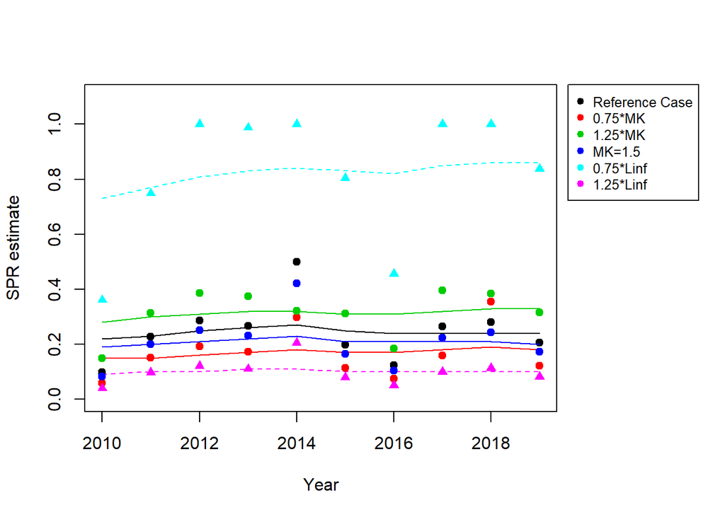

```r
smoothEsts1 <- data.frame(Fit1@Ests)
smoothEsts1MK <- data.frame(Fit0.75MK@Ests)
smoothEsts2MK <- data.frame(Fit1.25MK@Ests)
smoothEsts3MK <- data.frame(Fit1.5MK@Ests)
smoothEsts1Linf <- data.frame(Fit0.75Linf@Ests)
smoothEsts2Linf <- data.frame(Fit1.25Linf@Ests)

spr1 <- Fit1@SPR
sprmk1 <- Fit0.75MK@SPR
sprmk2 <- Fit1.25MK@SPR
sprmk3 <- Fit1.5MK@SPR
sprL1 <- Fit0.75Linf@SPR
sprL2 <- Fit1.25Linf@SPR

par(mar=c(5.1, 4.1, 4.1, 8.1), xpd=TRUE)

plot(c(2010:2019),spr1,ylim=c(0,1.1),xlab="Year",ylab="SPR estimate",pch=19)

lines(2010:2019, smoothEsts1$SPR, lwd = 1,col="black")
lines(2010:2019, smoothEsts1MK$SPR, lwd = 1, col=2)
lines(2010:2019, smoothEsts2MK$SPR, lwd = 1, col=3)
lines(2010:2019, smoothEsts3MK$SPR, lwd = 1, col=4)
lines(2010:2019, smoothEsts1Linf$SPR, lwd = 1, lty = 2, col=5)
lines(2010:2019, smoothEsts2Linf$SPR, lwd = 1, lty=2 ,col=6)


points(2010:2019, sprmk1,col=2,pch=19)
points(2010:2019, sprmk2,col=3,pch=19)
points(2010:2019, sprmk3,col=4,pch=19)
points(2010:2019, sprL1,col=5,pch=17)
points(2010:2019, sprL2,col=6, pch=17)

legend("topright", inset=c(-0.3,0), legend=c("Reference Case", "0.75*MK","1.25*MK","MK=1.5","0.75*Linf","1.25*Linf"),
       col=c("black", 2:6), pch=19, cex=0.8)
```

Plot F/M:

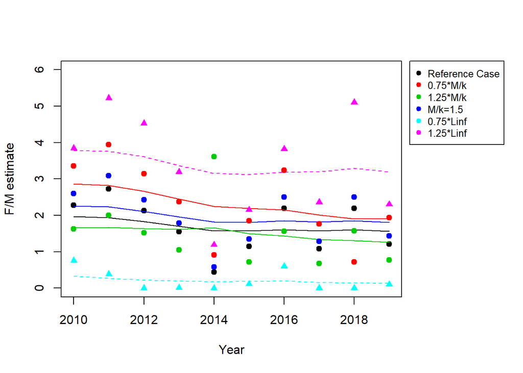

```r
fm1=Fit1@FM
fmmk1=Fit0.75MK@FM
fmmk2=Fit1.25MK@FM
fmmk3=Fit1.5MK@FM
fmL1=Fit0.75Linf@FM
fmL2=Fit1.25Linf@FM

par(mar=c(5.1, 4.1, 4.1, 8.1), xpd=TRUE)

plot(2010:2019,fm1,ylim=c(0,6),xlab="Year",ylab="F/M estimate",pch=19)

lines(2010:2019, smoothEsts1$FM, lwd = 1,col="black")
lines(2010:2019, smoothEsts1MK$FM, lwd = 1,col=2)
lines(2010:2019, smoothEsts2MK$FM, lwd = 1,col=3)
lines(2010:2019, smoothEsts3MK$FM, lwd = 1,col=4)
lines(2010:2019, smoothEsts1Linf$FM, lwd = 1,lty= 2, col=5)
lines(2010:2019, smoothEsts2Linf$FM, lwd = 1,lty= 2, col=6)


points(2010:2019, fmmk1,col=2,pch=19)
points(2010:2019, fmmk2,col=3,pch=19)
points(2010:2019, fmmk3,col=4,pch=19)
points(2010:2019, fmL1,col=5,pch=17)
points(2010:2019, fmL2,col=6,pch=17)
legend("topright", inset=c(-0.3,0), legend=c("Reference Case", "0.75*M/k","1.25*M/k","M/k=1.5","0.75*Linf","1.25*Linf"),
       col=c("black", 2:6), pch=19, cex=0.8)
```

### Conclusions

Remarkable changes were observed when comparing SPR estimates between the four tested M/k values and three Linf values. SPR estimates were strongly influenced by the input Linf value, being negatively correlated with increasing asymptotic length. SPR estimates for 2019 across Linf values were as follows: 0.84, 0.21 and 0.08 at Linf values of 73.6, 98.2 and 122.7 cm. Using a higher M/k value produces an overestimation of SPR. Assuming M/k values of 1.2, 1.5, 1.7 and 2.1 the SPR estimates in 2019 were 0.12, 0.17, 0.21 and 0.31 respectively.

F/M estimates are greatly impacted by the Linf assumed value. High values of Linf lead to higher F/M estimates. The value of the invariant M/k had a more moderate effect on the F/M estimate than the Linf. It was observed that F/M is negatively correlated with M/k: higher M/k values produce lower F/M estimates.

### References

Alemany, J. 2017. Développement d’un cadre Bayésien pour l’évaluation de stocks à données limitées et élaboration de scénarios de gestion, cas particuliers de la seiche (Sepia officinalis) et du lieu jaune (Pollachius pollachius). Ph.D. Thesis. Université Caen Normandie. 262 pp.

Alonso-Fernández A., Villegas-Rios, D., Valdés-López, M., Olveira-Rodríguez, B. and F. Saborido-Rey. 2013. Reproductive biology of pollack (Pollachius pollachius) from the Galician shelf (North-West Spain). Journal of the Marine Biological Association of the United Kingdom, 2013, 93(7): 1951-1963.